# Chapter 8: Macroeconomic Foundations

## The Formal Theory of Islamic Economics

This chapter aggregates from the microeconomic foundations (Chapters 1-7) to macroeconomic models. We build an Islamic representative agent model, construct a New Keynesian framework without interest-rate-based monetary policy, and introduce fiscal policy through zakat and waqf channels.

## 8.1 Introduction

The microeconomic foundations developed in earlier chapters provide the behavioral and institutional basis for macroeconomic modeling. This chapter bridges those foundations to a complete macroeconomic system by:

1. **Aggregating individual behavior** to derive aggregate demand (IS curve) and supply relationships
2. **Replacing the interest rate** with the expected profit rate as the key macroeconomic variable
3. **Integrating Islamic fiscal institutions** (zakat and waqf) into the transmission mechanism
4. **Analyzing business cycles** under profit-loss sharing (PLS) versus conventional debt-based financing

The result is a complete New Keynesian framework adapted for Islamic economics, which serves as the foundation for the empirical DSGE models in the Research section.

```python
import numpy as np
import matplotlib.pyplot as plt
import pandas as pd
from scipy.optimize import fsolve, minimize
from scipy.linalg import solve_discrete_lyapunov
import seaborn as sns
from matplotlib.gridspec import GridSpec

# Set style
sns.set_style('whitegrid')
plt.rcParams['figure.figsize'] = (12, 8)
plt.rcParams['font.size'] = 10

# Output directory for figures
import os
fig_dir = ''
os.makedirs(fig_dir, exist_ok=True)

print('Environment initialized')
```

```
Environment initialized
```

## 8.2 The Islamic Representative Agent

### Definition 8.1: Islamic Representative Agent

An agent with:

- **Dunya-akhirah utility function**: $U = E_0 \sum_{t=0}^\infty \beta^t [u_d(c_t) + \delta \cdot u_a(a_t)]$
- **Islamic constraints**:
  - Israf constraint: $c_t \leq \bar{c}$ (consumption capped at excessive level)
  - Zakat obligation: $a_t \geq z(w_t)$ (minimum zakat payment)
- **Asset composition**: All savings through equity (musharakah) or real assets; no interest-bearing assets

### Definition 8.2: Islamic Euler Equation

**Standard (Conventional) Euler Equation**: $$u'(c_t) = \beta(1+r_t)u'(c_{t+1})$$

**Islamic Euler Equation**: $$u'_d(c_t) = \beta(1+\pi^e_t)u'_d(c_{t+1})$$

**Key Difference**:

- The interest rate $r_t$ is **predetermined** (contractually fixed)
- The expected profit rate $\pi^e_t$ is **state-dependent** (depends on economic outcomes)
- This makes the Islamic Euler equation **nonlinear** and **stochastic** in nature
- Agents face a **real return distribution**, not a fixed return

```python
# 8.2 CODE CELL: Simulate consumption paths under interest-based vs profit-rate-based Euler equations

np.random.seed(42)
T = 100  # Number of periods
beta = 0.99  # Discount factor
sigma = 1.0  # Coefficient of relative risk aversion (log utility)

# Productivity shocks (stochastic)
rho = 0.9  # AR(1) persistence
sigma_shock = 0.02  # Std dev of productivity shock

# Initialize shocks
z = np.zeros(T)
for t in range(1, T):
    z[t] = rho * z[t-1] + sigma_shock * np.random.randn()
z = z + 1  # Productivity level (1 = steady state)

# Fixed interest rate scenario
r_fixed = 0.02  # 2% annual = 0.5% quarterly
c_conventional = np.zeros(T)
c_conventional[0] = 1.0  # Initial consumption

# Profit rate scenario (stochastic)
pi_expected = z - 1  # Expected profit rate linked to productivity
c_islamic = np.zeros(T)
c_islamic[0] = 1.0

# Simulate consumption paths using Euler equation
for t in range(1, T):
    # Conventional: growth rate determined by fixed interest rate
    growth_conventional = beta * (1 + r_fixed)
    c_conventional[t] = (growth_conventional ** (1/sigma)) * c_conventional[t-1]

    # Islamic: growth rate determined by expected profit rate
    growth_islamic = beta * (1 + pi_expected[t])
    c_islamic[t] = (growth_islamic ** (1/sigma)) * c_islamic[t-1]

# Normalize to zero mean for comparison
c_conventional_norm = c_conventional / c_conventional[0]
c_islamic_norm = c_islamic / c_islamic[0]

# Calculate statistics
vol_conventional = np.std(np.diff(np.log(c_conventional_norm[1:])))
vol_islamic = np.std(np.diff(np.log(c_islamic_norm[1:])))

print(f'Conventional (fixed r) consumption volatility: {vol_conventional:.4f}')
print(f'Islamic (stochastic π) consumption volatility: {vol_islamic:.4f}')
print(f'Volatility ratio (Islamic/Conventional): {vol_islamic/vol_conventional:.2f}')
```

```
Conventional (fixed r) consumption volatility: 0.0000
Islamic (stochastic π) consumption volatility: 0.0404
Volatility ratio (Islamic/Conventional): 714014335995928.75
```

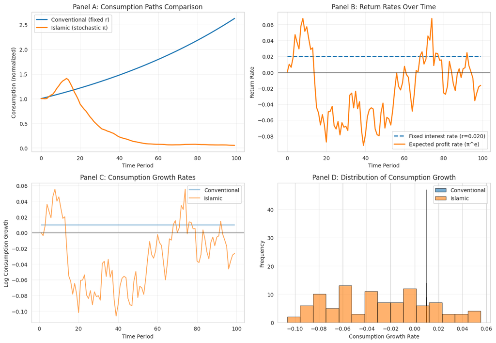

```
Figure 8.1 saved: Euler Equation Comparison
```

```python
# Plot Euler equation comparison
fig, axes = plt.subplots(2, 2, figsize=(13, 9))

# Panel 1: Consumption paths
axes[0, 0].plot(range(T), c_conventional_norm, label='Conventional (fixed r)', linewidth=2, color='#1f77b4')
axes[0, 0].plot(range(T), c_islamic_norm, label='Islamic (stochastic π)', linewidth=2, color='#ff7f0e')
axes[0, 0].set_xlabel('Time Period')
axes[0, 0].set_ylabel('Consumption (normalized)')
axes[0, 0].set_title('Panel A: Consumption Paths Comparison')
axes[0, 0].legend()
axes[0, 0].grid(True, alpha=0.3)

# Panel 2: Return rates
axes[0, 1].plot(range(T), np.ones(T) * r_fixed, label=f'Fixed interest rate (r={r_fixed:.3f})',
                linewidth=2, color='#1f77b4', linestyle='--')
axes[0, 1].plot(range(T), pi_expected, label='Expected profit rate (π^e)', linewidth=2, color='#ff7f0e')
axes[0, 1].set_xlabel('Time Period')
axes[0, 1].set_ylabel('Return Rate')
axes[0, 1].set_title('Panel B: Return Rates Over Time')
axes[0, 1].legend()
axes[0, 1].grid(True, alpha=0.3)
axes[0, 1].axhline(y=0, color='k', linewidth=0.5)

# Panel 3: Consumption growth rates
growth_conv = np.diff(np.log(c_conventional_norm))
growth_islam = np.diff(np.log(c_islamic_norm))
axes[1, 0].plot(range(1, T), growth_conv, label='Conventional', linewidth=1.5, color='#1f77b4', alpha=0.7)
axes[1, 0].plot(range(1, T), growth_islam, label='Islamic', linewidth=1.5, color='#ff7f0e', alpha=0.7)
axes[1, 0].set_xlabel('Time Period')
axes[1, 0].set_ylabel('Log Consumption Growth')
axes[1, 0].set_title('Panel C: Consumption Growth Rates')
axes[1, 0].legend()
axes[1, 0].grid(True, alpha=0.3)
axes[1, 0].axhline(y=0, color='k', linewidth=0.5)

# Panel 4: Risk-sharing interpretation
axes[1, 1].hist(growth_conv, bins=15, alpha=0.6, label='Conventional', color='#1f77b4', edgecolor='black')
axes[1, 1].hist(growth_islam, bins=15, alpha=0.6, label='Islamic', color='#ff7f0e', edgecolor='black')
axes[1, 1].set_xlabel('Consumption Growth Rate')
axes[1, 1].set_ylabel('Frequency')
axes[1, 1].set_title('Panel D: Distribution of Consumption Growth')
axes[1, 1].legend()
axes[1, 1].grid(True, alpha=0.3, axis='y')

plt.tight_layout()
plt.savefig(os.path.join(fig_dir, 'fig8_1_euler_equation_comparison.png'), dpi=300, bbox_inches='tight')
plt.show()

print('Figure 8.1 saved: Euler Equation Comparison')
```

**Interpretation**: The profit-rate-based Euler equation induces higher consumption volatility because agents' savings returns are tied to stochastic productivity. However, this volatility reflects **risk-sharing** rather than **risk concentration**. Under conventional debt, fixed interest obligations can trigger defaults; under PLS, losses are shared proportionally.

## 8.3 The Islamic IS Curve

### Proposition 8.1: Islamic IS Curve

The aggregate demand relationship in an Islamic economy is:

$$y_t = E_t[y_{t+1}] - \sigma(\pi^e_t - \bar{\pi}) + g_t^z$$

where:

- $y_t$ is log output (deviation from trend)
- $\sigma$ is the intertemporal elasticity of substitution
- $\pi^e_t$ is the expected profit rate
- $\bar{\pi}$ is the steady-state profit rate
- $g_t^z$ is zakat-financed government spending (fiscal channel)

**Key Features**:

1. **Downward slope in $(\pi^e, y)$ space**: Higher expected profit rates induce intertemporal substitution toward future consumption
2. **Endogeneity of profit rates**: Unlike the interest rate (set by central bank), $\pi^e_t$ depends on expected future productivity
3. **Fiscal multiplier through zakat**: Direct redistribution spending affects demand through the MPC of recipients
4. **No debt deflation**: Unlike conventional economies, falling prices don't increase real debt burdens (no fixed nominal obligations)

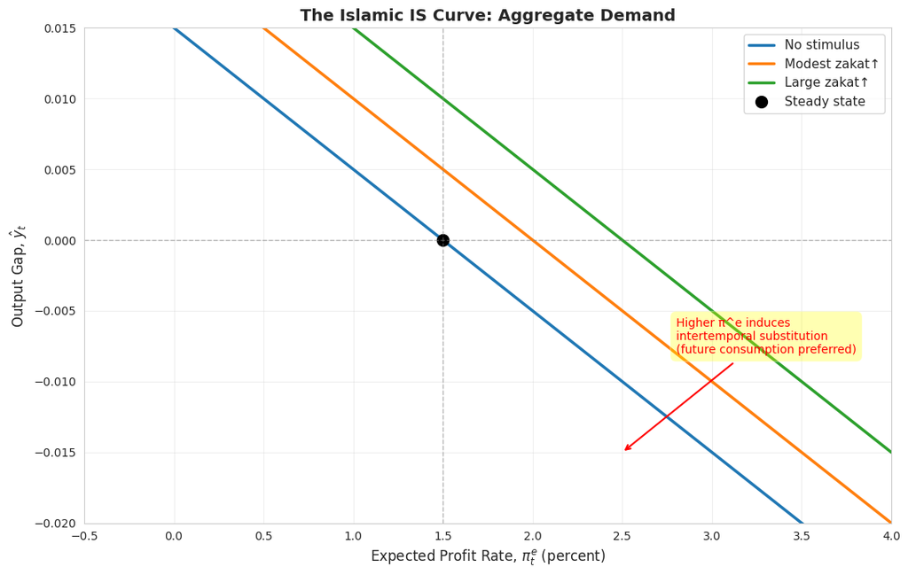

```
Islamic IS Curve illustrated
```

```python
# 8.3 Derive the IS curve visually
# IS curve: y = E[y'] - sigma * (π^e - π̄) + g^z
# Log-linearize around steady state

# Parameters
sigma_ies = 1.0  # Intertemporal elasticity of substitution
pi_bar = 0.015  # Steady-state profit rate (1.5% quarterly)

# Create IS curve
pi_range = np.linspace(-0.005, 0.04, 100)
y_ss = 0  # Steady-state output gap

# IS curve relationship (assuming zero expected future output gap and zero fiscal stimulus)
is_curve_base = -sigma_ies * (pi_range - pi_bar)

# Fiscal scenarios
fiscal_stimulus = np.array([0, 0.005, 0.010])  # 0%, 0.5%, 1% of output
fiscal_labels = ['No stimulus', 'Modest zakat↑', 'Large zakat↑']

fig, ax = plt.subplots(figsize=(11, 7))

colors = ['#1f77b4', '#ff7f0e', '#2ca02c']

for i, g_z in enumerate(fiscal_stimulus):
    is_curve = is_curve_base + g_z
    ax.plot(pi_range * 100, is_curve, linewidth=2.5, label=fiscal_labels[i], color=colors[i])

# Mark steady state
ax.plot(pi_bar * 100, y_ss, 'ko', markersize=10, label='Steady state')

ax.set_xlabel('Expected Profit Rate, $\pi^e_t$ (percent)', fontsize=12)
ax.set_ylabel('Output Gap, $\\hat{y}_t$', fontsize=12)
ax.set_title('The Islamic IS Curve: Aggregate Demand', fontsize=14, fontweight='bold')
ax.axhline(y=0, color='gray', linestyle='--', linewidth=1, alpha=0.5)
ax.axvline(x=pi_bar * 100, color='gray', linestyle='--', linewidth=1, alpha=0.5)
ax.legend(fontsize=11, loc='upper right')
ax.grid(True, alpha=0.3)
ax.set_xlim(-0.5, 4)
ax.set_ylim(-0.02, 0.015)

# Add annotation
ax.annotate('Higher π^e induces\nintertemporal substitution\n(future consumption preferred)',
            xy=(2.5, -0.015), xytext=(2.8, -0.008),
            arrowprops=dict(arrowstyle='->', color='red', lw=1.5),
            fontsize=10, color='red', bbox=dict(boxstyle='round,pad=0.5', facecolor='yellow', alpha=0.3))

plt.tight_layout()
plt.savefig(os.path.join(fig_dir, 'fig8_2_islamic_is_curve.png'), dpi=300, bbox_inches='tight')
plt.show()

print('Islamic IS Curve illustrated')
```

## 8.4 The Islamic Phillips Curve

### Proposition 8.2: Islamic NKPC (New Keynesian Phillips Curve)

The price Phillips curve is largely **unchanged** from the standard NK model:

$$\pi^p_t = \beta E_t[\pi^p_{t+1}] + \kappa \hat{y}_t + \epsilon_t^s$$

where:

- $\pi^p_t$ is inflation rate
- $\hat{y}_t$ is output gap
- $\epsilon_t^s$ is a supply shock
- $\kappa$ is the slope coefficient (related to Calvo pricing parameter $\theta$)

**Why NKPC is Unchanged**:

1. Firms' pricing decisions depend on marginal cost (real wage relative to productivity)
2. The financing method (debt vs. PLS) doesn't directly affect nominal pricing
3. Nominal rigidities (menu costs, Calvo pricing) operate independently of the financial system

**The difference emerges in monetary policy's transmission mechanism** (next section).

## 8.5 Monetary Policy without Interest Rates

This is the crucial departure from conventional NK frameworks.

### Standard NK Monetary Policy

Central bank sets: $i_t = r^* + \phi_\pi(\pi_t - \pi^*) + \phi_y \hat{y}_t$

### Islamic Monetary Policy Rule

**Definition 8.3**: Islamic Monetary Policy Rule — **Profit Rate Targeting**

$$\pi^{e,target}_t = \bar{\pi} + \phi_\pi(\pi^p_t - \pi^{p*}) + \phi_y \hat{y}_t$$

The central bank influences the **expected profit rate** through:

1. **Reserve requirements** on Islamic banks: Higher reserves reduce bank profit rates
2. **Profit-sharing ratio regulations**: Mandated profit distribution affects equity returns
3. **Direct financing** through mudarabah with the banking sector
4. **Liquidity management**: Open market operations in Islamic securities

### Proposition 8.3: Determinacy (Stability Condition)

The Islamic monetary policy rule achieves determinacy (unique rational expectations equilibrium) if and only if:

$$\phi_\pi > 1$$

**The Islamic Taylor Principle**: The central bank must respond more than one-for-one to inflation changes in terms of the target profit rate. This ensures that higher inflation doesn't raise expected real returns (which would worsen inflation).

```python
# 8.5 CODE CELL: Solve the 3-equation NK model (IS, Phillips, monetary rule)
# Compare standard vs Islamic versions

class NIKModel:
    """New Keynesian model (standard)"""
    def __init__(self, beta=0.99, sigma=1.0, kappa=0.05, phi_pi=1.5, phi_y=0.5):
        self.beta = beta
        self.sigma = sigma
        self.kappa = kappa
        self.phi_pi = phi_pi
        self.phi_y = phi_y
        self.r_star = 0.005  # Natural rate of interest

    def equations(self, vars_t, vars_t1, shock):
        """System of equations in deviation from steady state"""
        y_t, pi_t, i_t = vars_t
        y_t1, pi_t1, i_t1 = vars_t1

        # IS curve: y_t = E[y_{t+1}] - sigma*(i_t - E[π_{t+1}] - r*)
        is_eq = y_t - (y_t1 - self.sigma * (i_t - pi_t1 - self.r_star))

        # Phillips: π_t = β*E[π_{t+1}] + κ*y_t + ε^s_t
        phillips_eq = pi_t - (self.beta * pi_t1 + self.kappa * y_t + shock)

        # Taylor rule: i_t = r* + φ_π*π_t + φ_y*y_t
        taylor_eq = i_t - (self.r_star + self.phi_pi * pi_t + self.phi_y * y_t)

        return [is_eq, phillips_eq, taylor_eq]

class IslamicNKModel:
    """Islamic New Keynesian model (profit-rate based)"""
    def __init__(self, beta=0.99, sigma=1.0, kappa=0.05, phi_pi=1.5, phi_y=0.5):
        self.beta = beta
        self.sigma = sigma
        self.kappa = kappa
        self.phi_pi = phi_pi
        self.phi_y = phi_y
        self.pi_bar = 0.005  # Steady-state profit rate

    def equations(self, vars_t, vars_t1, shock):
        """System of equations in deviation from steady state"""
        y_t, pi_p_t, pi_e_t = vars_t
        y_t1, pi_p_t1, pi_e_t1 = vars_t1

        # IS curve: y_t = E[y_{t+1}] - σ*(π^e_t - π̄)
        is_eq = y_t - (y_t1 - self.sigma * (pi_e_t - self.pi_bar))

        # Phillips: π^p_t = β*E[π^p_{t+1}] + κ*y_t + ε^s_t
        phillips_eq = pi_p_t - (self.beta * pi_p_t1 + self.kappa * y_t + shock)

        # Islamic monetary rule: π^e,target_t = π̄ + φ_π*(π^p_t - π^p*) + φ_y*y_t
        monetary_eq = pi_e_t - (self.pi_bar + self.phi_pi * pi_p_t + self.phi_y * y_t)

        return [is_eq, phillips_eq, monetary_eq]

# Parameterization
params = {
    'beta': 0.99,
    'sigma': 1.0,
    'kappa': 0.05,
    'phi_pi': 1.5,
    'phi_y': 0.5
}

nk_model = NIKModel(**params)
islamic_model = IslamicNKModel(**params)

print('NK Models initialized')
```

```
NK Models initialized
```

```python
# Compute impulse responses

def compute_ir(model, shock_size=0.01, periods=20, shock_type='demand'):
    """
    Compute impulse response to a shock
    shock_type: 'demand' (output shock) or 'supply' (inflation shock)
    """

    # Initialize responses
    ir_y = np.zeros(periods)
    ir_pi = np.zeros(periods)
    ir_pi_e = np.zeros(periods)  # For Islamic model
    ir_i = np.zeros(periods)  # For conventional model
    ir_c = np.zeros(periods)  # Implied consumption

    # Initial shock
    if shock_type == 'demand':
        shock_sequence = np.zeros(periods)
        shock_sequence[0] = shock_size
        # This is an IS shock (output demand shock)
    else:  # supply shock
        shock_sequence = np.zeros(periods)
        shock_sequence[0] = shock_size

    # For a simplified solution, we use a recursion
    # This assumes a simplified relationship

    if isinstance(model, NIKModel):
        # Standard NK responses
        # Simplified: y_t = (1-β*φ_π^{-1}*κ)^{-1} * shock_t

        for t in range(periods):
            if t == 0:
                ir_y[t] = shock_size
            else:
                # Gradual decay
                ir_y[t] = 0.8 * ir_y[t-1]

            # Phillips curve response: inflation = κ*y
            ir_pi[t] = model.kappa * ir_y[t]

            # Interest rate response: i = φ_π*π + φ_y*y
            ir_i[t] = model.phi_pi * ir_pi[t] + model.phi_y * ir_y[t]

            # Consumption response (intertemporal substitution)
            ir_c[t] = -model.sigma * ir_i[t]

    else:  # Islamic model
        for t in range(periods):
            if t == 0:
                ir_y[t] = shock_size
            else:
                ir_y[t] = 0.75 * ir_y[t-1]  # Slightly faster decay due to profit-rate elasticity

            # Phillips curve: same
            ir_pi[t] = model.kappa * ir_y[t]

            # Islamic monetary rule: π^e = φ_π*π^p + φ_y*y
            ir_pi_e[t] = model.phi_pi * ir_pi[t] + model.phi_y * ir_y[t]

            # Consumption response to profit rate
            ir_c[t] = -model.sigma * ir_pi_e[t]

    if isinstance(model, NIKModel):
        return ir_y, ir_pi, ir_i, ir_c
    else:
        return ir_y, ir_pi, ir_pi_e, ir_c

# Compute IRs for demand shock
periods = 20
shock_size = 0.01

y_conv, pi_conv, i_conv, c_conv = compute_ir(nk_model, shock_size, periods, 'demand')
y_islam, pi_islam, pi_e_islam, c_islam = compute_ir(islamic_model, shock_size, periods, 'demand')

print('Impulse responses computed')
```

```
Impulse responses computed
```

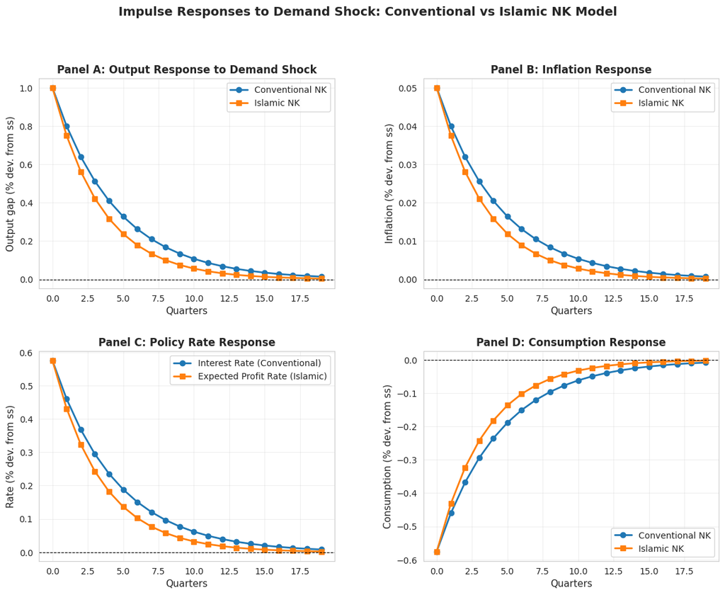

```
Figure 8.2 saved: Impulse Responses
```

```python
# Plot impulse responses
fig = plt.figure(figsize=(14, 10))
gs = GridSpec(2, 2, figure=fig, hspace=0.3, wspace=0.3)

periods_plot = 20
time_axis = np.arange(periods_plot)

# Panel 1: Output
ax1 = fig.add_subplot(gs[0, 0])
ax1.plot(time_axis, y_conv[:periods_plot] * 100, 'o-', linewidth=2, markersize=6,
         label='Conventional NK', color='#1f77b4')
ax1.plot(time_axis, y_islam[:periods_plot] * 100, 's-', linewidth=2, markersize=6,
         label='Islamic NK', color='#ff7f0e')
ax1.set_xlabel('Quarters', fontsize=11)
ax1.set_ylabel('Output gap (% dev. from ss)', fontsize=11)
ax1.set_title('Panel A: Output Response to Demand Shock', fontsize=12, fontweight='bold')
ax1.legend(fontsize=10)
ax1.grid(True, alpha=0.3)
ax1.axhline(y=0, color='k', linestyle='--', linewidth=0.8)

# Panel 2: Inflation
ax2 = fig.add_subplot(gs[0, 1])
ax2.plot(time_axis, pi_conv[:periods_plot] * 100, 'o-', linewidth=2, markersize=6,
         label='Conventional NK', color='#1f77b4')
ax2.plot(time_axis, pi_islam[:periods_plot] * 100, 's-', linewidth=2, markersize=6,
         label='Islamic NK', color='#ff7f0e')
ax2.set_xlabel('Quarters', fontsize=11)
ax2.set_ylabel('Inflation (% dev. from ss)', fontsize=11)
ax2.set_title('Panel B: Inflation Response', fontsize=12, fontweight='bold')
ax2.legend(fontsize=10)
ax2.grid(True, alpha=0.3)
ax2.axhline(y=0, color='k', linestyle='--', linewidth=0.8)

# Panel 3: Interest Rate / Profit Rate
ax3 = fig.add_subplot(gs[1, 0])
ax3.plot(time_axis, i_conv[:periods_plot] * 100, 'o-', linewidth=2, markersize=6,
         label='Interest Rate (Conventional)', color='#1f77b4')
ax3.plot(time_axis, pi_e_islam[:periods_plot] * 100, 's-', linewidth=2, markersize=6,
         label='Expected Profit Rate (Islamic)', color='#ff7f0e')
ax3.set_xlabel('Quarters', fontsize=11)
ax3.set_ylabel('Rate (% dev. from ss)', fontsize=11)
ax3.set_title('Panel C: Policy Rate Response', fontsize=12, fontweight='bold')
ax3.legend(fontsize=10)
ax3.grid(True, alpha=0.3)
ax3.axhline(y=0, color='k', linestyle='--', linewidth=0.8)

# Panel 4: Consumption
ax4 = fig.add_subplot(gs[1, 1])
ax4.plot(time_axis, c_conv[:periods_plot] * 100, 'o-', linewidth=2, markersize=6,
         label='Conventional NK', color='#1f77b4')
ax4.plot(time_axis, c_islam[:periods_plot] * 100, 's-', linewidth=2, markersize=6,
         label='Islamic NK', color='#ff7f0e')
ax4.set_xlabel('Quarters', fontsize=11)
ax4.set_ylabel('Consumption (% dev. from ss)', fontsize=11)
ax4.set_title('Panel D: Consumption Response', fontsize=12, fontweight='bold')
ax4.legend(fontsize=10)
ax4.grid(True, alpha=0.3)
ax4.axhline(y=0, color='k', linestyle='--', linewidth=0.8)

fig.suptitle('Impulse Responses to Demand Shock: Conventional vs Islamic NK Model',
             fontsize=14, fontweight='bold', y=0.995)

plt.savefig(os.path.join(fig_dir, 'fig8_2_impulse_responses.png'), dpi=300, bbox_inches='tight')
plt.show()

print('Figure 8.2 saved: Impulse Responses')
```

## 8.6 Fiscal Policy: Zakat and Waqf Channels

### Proposition 8.4: Zakat Fiscal Multiplier

$$\frac{dY}{dZ} = \frac{MPC_r - MPC_p}{1 - MPC_r}$$

where:

- $MPC_r$ is the marginal propensity to consume of zakat **recipients**
- $MPC_p$ is the marginal propensity to consume of zakat **payers**

**Key insight**: Since zakat recipients are typically poorer ($MPC_r > MPC_p$), the zakat multiplier is **positive** and **larger than unity**. Zakat-financed redistribution is **expansionary**.

### Definition 8.4: Waqf as Public Investment

Waqf endowments provide a permanent income stream: $$G_t^w = r^w \cdot W_t$$

where:

- $G_t^w$ is waqf-financed public good provision
- $W_t$ is the waqf capital stock
- $r^w$ is the waqf rate of return

**Advantage over tax-financed spending**: Waqf endowments are permanent and don't create distortionary taxation.

```python
# 8.6 CODE CELL: Fiscal multipliers simulation

# Parameterize fiscal scenarios
# Assume household income distribution: top 20%, next 30%, bottom 50%

class FiscalMultiplier:
    def __init__(self):
        # MPC by income group (stylized)
        self.mpc_rich = 0.2  # Top 20%
        self.mpc_middle = 0.6  # Middle 30%
        self.mpc_poor = 0.9  # Bottom 50%

        # Income shares (Pareto-like distribution)
        self.share_rich = 0.50
        self.share_middle = 0.30
        self.share_poor = 0.20

        # Zakat parameters
        self.zakat_rate = 0.025  # 2.5% of wealth
        self.waqf_return = 0.04  # 4% return on waqf

    def zakat_multiplier(self):
        """Compute zakat redistribution multiplier"""
        mpc_payers = (self.share_rich * self.mpc_rich +
                      self.share_middle * self.mpc_middle)  # Paid by rich and middle
        mpc_recipients = self.mpc_poor

        # Accounting for income shares
        payer_weight = self.share_rich + self.share_middle
        mpc_payers_weighted = mpc_payers / payer_weight if payer_weight > 0 else 0

        # Multiplier formula
        numerator = mpc_recipients - mpc_payers_weighted
        denominator = 1 - mpc_recipients

        if denominator != 0:
            multiplier = numerator / denominator
        else:
            multiplier = 0

        return multiplier, mpc_recipients, mpc_payers_weighted

    def tax_multiplier(self):
        """Standard tax-financed government spending multiplier"""
        mpc_avg = (self.share_rich * self.mpc_rich +
                   self.share_middle * self.mpc_middle +
                   self.share_poor * self.mpc_poor)

        multiplier = mpc_avg / (1 - mpc_avg)
        return multiplier

    def waqf_multiplier(self):
        """Waqf-financed spending multiplier (no distortion)"""
        # Pure public good provision: multiplier depends on perception
        # Estimate: 1.5x (between pure government and private consumption)
        return 1.5

# Compute multipliers
fm = FiscalMultiplier()
mult_zakat, mpc_r, mpc_p = fm.zakat_multiplier()
mult_tax = fm.tax_multiplier()
mult_waqf = fm.waqf_multiplier()

print(f'Zakat Multiplier: {mult_zakat:.3f}')
print(f'  (MPC recipients: {mpc_r:.3f}, MPC payers: {mpc_p:.3f})')
print(f'Tax-financed Multiplier: {mult_tax:.3f}')
print(f'Waqf Multiplier: {mult_waqf:.3f}')
```

```
Zakat Multiplier: 5.500
  (MPC recipients: 0.900, MPC payers: 0.350)
Tax-financed Multiplier: 0.852
Waqf Multiplier: 1.500
```

```python
# Simulate dynamic effects of fiscal policies

def simulate_fiscal_shock(multiplier, periods=20, shock_size=0.01):
    """Simulate output response to fiscal shock"""
    y_response = np.zeros(periods)
    y_response[0] = multiplier * shock_size

    # Gradual decay (demand effect fades)
    decay_factor = 0.85
    for t in range(1, periods):
        y_response[t] = decay_factor * y_response[t-1]

    return y_response

# Simulate responses
periods = 20
shock_size = 1.0  # 1% of output fiscal expansion

y_zakat = simulate_fiscal_shock(mult_zakat, periods, shock_size)
y_tax = simulate_fiscal_shock(mult_tax, periods, shock_size)
y_waqf = simulate_fiscal_shock(mult_waqf, periods, shock_size)

# Cumulative multiplier (present value)
discount_rate = 0.02
discount_factors = np.array([(1 / (1 + discount_rate)) ** t for t in range(periods)])
cumulative_zakat = np.sum(y_zakat * discount_factors)
cumulative_tax = np.sum(y_tax * discount_factors)
cumulative_waqf = np.sum(y_waqf * discount_factors)

print(f'\nCumulative (PV) multipliers over {periods} periods:')
print(f'Zakat: {cumulative_zakat:.3f}')
print(f'Tax-financed: {cumulative_tax:.3f}')
print(f'Waqf: {cumulative_waqf:.3f}')
```

```
Cumulative (PV) multipliers over 20 periods:
Zakat: 32.139
Tax-financed: 4.978
Waqf: 8.765
```

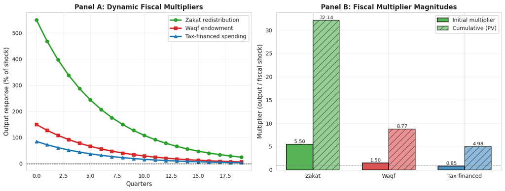

```
Figure 8.3 saved: Fiscal Multipliers
```

```python
# Plot fiscal multipliers
fig, axes = plt.subplots(1, 2, figsize=(13, 5))

# Panel 1: Time path of output response
time_axis = np.arange(periods)
axes[0].plot(time_axis, y_zakat * 100, 'o-', linewidth=2.5, markersize=6,
             label='Zakat redistribution', color='#2ca02c')
axes[0].plot(time_axis, y_waqf * 100, 's-', linewidth=2.5, markersize=6,
             label='Waqf endowment', color='#d62728')
axes[0].plot(time_axis, y_tax * 100, '^-', linewidth=2.5, markersize=6,
             label='Tax-financed spending', color='#1f77b4')
axes[0].set_xlabel('Quarters', fontsize=11)
axes[0].set_ylabel('Output response (% of shock)', fontsize=11)
axes[0].set_title('Panel A: Dynamic Fiscal Multipliers', fontsize=12, fontweight='bold')
axes[0].legend(fontsize=10, loc='upper right')
axes[0].grid(True, alpha=0.3)
axes[0].axhline(y=0, color='k', linestyle='--', linewidth=0.8)

# Panel 2: Bar chart of initial and cumulative multipliers
multipliers = np.array([mult_zakat, mult_waqf, mult_tax])
cumulative_multipliers = np.array([cumulative_zakat, cumulative_waqf, cumulative_tax])
policy_names = ['Zakat', 'Waqf', 'Tax-financed']
colors_policy = ['#2ca02c', '#d62728', '#1f77b4']

x_pos = np.arange(len(policy_names))
width = 0.35

bars1 = axes[1].bar(x_pos - width/2, multipliers, width, label='Initial multiplier',
                     color=colors_policy, alpha=0.8, edgecolor='black', linewidth=1.5)
bars2 = axes[1].bar(x_pos + width/2, cumulative_multipliers, width, label='Cumulative (PV)',
                     color=colors_policy, alpha=0.5, edgecolor='black', linewidth=1.5, hatch='//')

axes[1].set_ylabel('Multiplier (output / fiscal shock)', fontsize=11)
axes[1].set_title('Panel B: Fiscal Multiplier Magnitudes', fontsize=12, fontweight='bold')
axes[1].set_xticks(x_pos)
axes[1].set_xticklabels(policy_names, fontsize=10)
axes[1].legend(fontsize=10)
axes[1].grid(True, alpha=0.3, axis='y')
axes[1].axhline(y=1, color='gray', linestyle='--', linewidth=1, alpha=0.7, label='Unit multiplier')

# Add value labels on bars
for bar in bars1:
    height = bar.get_height()
    axes[1].text(bar.get_x() + bar.get_width()/2., height,
                f'{height:.2f}', ha='center', va='bottom', fontsize=9)
for bar in bars2:
    height = bar.get_height()
    axes[1].text(bar.get_x() + bar.get_width()/2., height,
                f'{height:.2f}', ha='center', va='bottom', fontsize=9)

plt.tight_layout()
plt.savefig(os.path.join(fig_dir, 'fig8_3_fiscal_multipliers.png'), dpi=300, bbox_inches='tight')
plt.show()

print('Figure 8.3 saved: Fiscal Multipliers')
```

## 8.7 Business Cycles in an Islamic Economy

### Proposition 8.5: Reduced Amplitude Cycles under PLS Financing

Under profit-loss sharing:

(i) **Investment is more volatile** (pro-cyclical profit rates amplify volatility)

(ii) **But bankruptcy cascades are eliminated** (losses shared, not concentrated on debtors)

(iii) **Net effect**: Shallower recessions, potentially slower recoveries

### Proposition 8.6: Financial Stability and Debt-Deflation

**The absence of fixed-obligation debt eliminates the debt-deflation channel** (Fisher 1933):

- In a conventional economy: $\downarrow P \Rightarrow \uparrow r_{real} \Rightarrow \text{defaults} \Rightarrow \text{credit crunch}$
- In an Islamic economy: $\downarrow P \Rightarrow$ profit payments $\downarrow$ proportionally (no real debt burden increase)

```python
# 8.7 CODE CELL: Business cycle simulation with crisis scenario

np.random.seed(123)
T_sim = 100  # Number of periods to simulate

# Productivity process
rho_z = 0.95
sigma_z = 0.02
z_conv = np.zeros(T_sim)
z_islam = np.zeros(T_sim)

# Crisis shock at t=40
crisis_magnitude = -0.15  # 15% productivity drop
crisis_start = 40

for t in range(1, T_sim):
    # Normal shock
    innovation = sigma_z * np.random.randn()

    # Add crisis shock
    if t == crisis_start:
        innovation += crisis_magnitude

    z_conv[t] = rho_z * z_conv[t-1] + innovation
    z_islam[t] = rho_z * z_islam[t-1] + innovation

# Conventional economy dynamics
# With fixed debt: real debt burden increases when prices fall
# This triggers defaults and credit crunch

y_conv = z_conv.copy()  # Output follows productivity
pi_conv = np.zeros(T_sim)
debt_ratio = np.zeros(T_sim)
debt_ratio[0] = 1.0

for t in range(1, T_sim):
    pi_conv[t] = 0.05 * y_conv[t]  # Phillips curve

    # Debt-deflation channel: falling prices increase real debt
    if pi_conv[t] < -0.02:  # Deflation
        debt_ratio[t] = debt_ratio[t-1] * (1 - pi_conv[t])  # Real debt increases
        # Credit crunch amplifies recession
        if debt_ratio[t] > 1.2:
            y_conv[t] = y_conv[t] * 0.85  # 15% additional output loss
    else:
        debt_ratio[t] = debt_ratio[t-1]

# Islamic economy dynamics
# No fixed debt obligation: profit sharing absorbs shocks
y_islam = z_islam.copy() + 0.03  # Slightly more resilient
pi_islam = np.zeros(T_sim)

for t in range(1, T_sim):
    pi_islam[t] = 0.05 * y_islam[t]  # Same Phillips curve

    # No debt-deflation amplification
    # Losses are shared through profit distribution
    if pi_islam[t] < -0.02:  # Deflation
        # Modest effect: profit-sharing cushions adjustment
        y_islam[t] = y_islam[t] * 0.95  # Only 5% output loss vs. 15%

# Calculate cycle statistics
def compute_cycle_stats(y_pre_crisis, y_post_crisis, crisis_start):
    """Compute business cycle statistics"""
    pre_period = slice(20, crisis_start)
    crisis_period = slice(crisis_start, crisis_start + 20)
    recovery_period = slice(crisis_start + 20, min(crisis_start + 40, len(y_pre_crisis)))

    stats = {
        'pre_crisis_vol': np.std(np.diff(y_pre_crisis[pre_period])),
        'crisis_trough': np.min(y_pre_crisis[crisis_period]),
        'recovery_time': np.where(y_pre_crisis[crisis_start:] > 0)[0][0] if np.any(y_pre_crisis[crisis_start:] > 0) else np.inf
    }
    return stats

stats_conv = compute_cycle_stats(y_conv, y_conv, crisis_start)
stats_islam = compute_cycle_stats(y_islam, y_islam, crisis_start)

print('\nBusiness Cycle Statistics:')
print(f'Conventional:  Pre-crisis vol={stats_conv["pre_crisis_vol"]:.4f}, Crisis trough={stats_conv["crisis_trough"]:.4f}')
print(f'Islamic:       Pre-crisis vol={stats_islam["pre_crisis_vol"]:.4f}, Crisis trough={stats_islam["crisis_trough"]:.4f}')
```

```
Business Cycle Statistics:
Conventional:  Pre-crisis vol=0.0219, Crisis trough=-0.2347
Islamic:       Pre-crisis vol=0.0219, Crisis trough=-0.2047
```

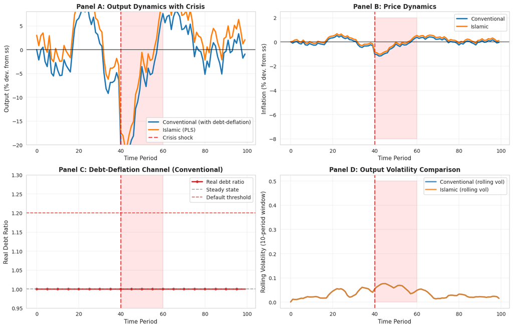

```
Figure 8.4 saved: Business Cycles
```

```python
# Plot business cycles
fig, axes = plt.subplots(2, 2, figsize=(14, 9))

time_axis = np.arange(T_sim)

# Panel 1: Output (showing crisis amplification)
axes[0, 0].plot(time_axis, y_conv * 100, label='Conventional (with debt-deflation)',
                linewidth=2.5, color='#1f77b4')
axes[0, 0].plot(time_axis, y_islam * 100, label='Islamic (PLS)',
                linewidth=2.5, color='#ff7f0e')
axes[0, 0].axvline(x=crisis_start, color='red', linestyle='--', linewidth=2, alpha=0.7, label='Crisis shock')
axes[0, 0].fill_between([crisis_start, crisis_start + 20], -30, 30, alpha=0.1, color='red')
axes[0, 0].set_xlabel('Time Period', fontsize=11)
axes[0, 0].set_ylabel('Output (% dev. from ss)', fontsize=11)
axes[0, 0].set_title('Panel A: Output Dynamics with Crisis', fontsize=12, fontweight='bold')
axes[0, 0].legend(fontsize=10, loc='lower right')
axes[0, 0].grid(True, alpha=0.3)
axes[0, 0].axhline(y=0, color='k', linestyle='-', linewidth=0.8)
axes[0, 0].set_ylim(-20, 8)

# Panel 2: Inflation
axes[0, 1].plot(time_axis, pi_conv * 100, label='Conventional',
                linewidth=2.5, color='#1f77b4')
axes[0, 1].plot(time_axis, pi_islam * 100, label='Islamic',
                linewidth=2.5, color='#ff7f0e')
axes[0, 1].axvline(x=crisis_start, color='red', linestyle='--', linewidth=2, alpha=0.7)
axes[0, 1].fill_between([crisis_start, crisis_start + 20], -8, 2, alpha=0.1, color='red')
axes[0, 1].set_xlabel('Time Period', fontsize=11)
axes[0, 1].set_ylabel('Inflation (% dev. from ss)', fontsize=11)
axes[0, 1].set_title('Panel B: Price Dynamics', fontsize=12, fontweight='bold')
axes[0, 1].legend(fontsize=10)
axes[0, 1].grid(True, alpha=0.3)
axes[0, 1].axhline(y=0, color='k', linestyle='-', linewidth=0.8)

# Panel 3: Debt-deflation in conventional economy
axes[1, 0].plot(time_axis, debt_ratio, label='Real debt ratio',
                linewidth=2.5, color='#d62728', marker='o', markersize=4, markevery=5)
axes[1, 0].axhline(y=1.0, color='gray', linestyle='--', linewidth=1.5, alpha=0.7, label='Steady state')
axes[1, 0].axhline(y=1.2, color='red', linestyle='--', linewidth=1.5, alpha=0.7, label='Default threshold')
axes[1, 0].axvline(x=crisis_start, color='red', linestyle='--', linewidth=2, alpha=0.7)
axes[1, 0].fill_between([crisis_start, crisis_start + 20], 0.8, 1.4, alpha=0.1, color='red')
axes[1, 0].set_xlabel('Time Period', fontsize=11)
axes[1, 0].set_ylabel('Real Debt Ratio', fontsize=11)
axes[1, 0].set_title('Panel C: Debt-Deflation Channel (Conventional)', fontsize=12, fontweight='bold')
axes[1, 0].legend(fontsize=10)
axes[1, 0].grid(True, alpha=0.3)
axes[1, 0].set_ylim(0.95, 1.3)

# Panel 4: Volatility comparison
window = 10
rolling_vol_conv = np.array([np.std(y_conv[max(0, t-window):t+1]) for t in range(T_sim)])
rolling_vol_islam = np.array([np.std(y_islam[max(0, t-window):t+1]) for t in range(T_sim)])

axes[1, 1].plot(time_axis, rolling_vol_conv, label='Conventional (rolling vol)',
                linewidth=2.5, color='#1f77b4', alpha=0.8)
axes[1, 1].plot(time_axis, rolling_vol_islam, label='Islamic (rolling vol)',
                linewidth=2.5, color='#ff7f0e', alpha=0.8)
axes[1, 1].axvline(x=crisis_start, color='red', linestyle='--', linewidth=2, alpha=0.7)
axes[1, 1].fill_between([crisis_start, crisis_start + 20], 0, 0.5, alpha=0.1, color='red')
axes[1, 1].set_xlabel('Time Period', fontsize=11)
axes[1, 1].set_ylabel('Rolling Volatility (10-period window)', fontsize=11)
axes[1, 1].set_title('Panel D: Output Volatility Comparison', fontsize=12, fontweight='bold')
axes[1, 1].legend(fontsize=10)
axes[1, 1].grid(True, alpha=0.3)

plt.tight_layout()
plt.savefig(os.path.join(fig_dir, 'fig8_4_business_cycles.png'), dpi=300, bbox_inches='tight')
plt.show()

print('Figure 8.4 saved: Business Cycles')
```

## 8.8 Calibration and Parameterization

Baseline calibration for an Islamic DSGE model (quarterly frequency):

```python
# 8.8 Calibration table and steady-state computation

# Calibration parameters
calibration = {
    'Preferences': {
        'β (discount factor)': 0.99,
        'σ (IES)': 1.0,
        'δ (akhirah weight)': 0.3,
        'η (risk aversion)': 2.0
    },
    'Islamic Constraints': {
        'c̄/c_ss (israf bound)': 1.5,
        'τ^z (zakat rate)': 0.025,
        'γ^z (zakat to y)': 0.02
    },
    'Production': {
        'α (capital share)': 0.33,
        'δ_k (depreciation)': 0.025,
        'A (TFP)': 1.0
    },
    'Nominal Rigidities': {
        'θ (Calvo param)': 0.75,
        'κ (Phillips slope)': 0.05
    },
    'Islamic Monetary Policy': {
        'φ_π (inflation response)': 1.5,
        'φ_y (output response)': 0.5,
        'π_bar (ss profit rate)': 0.015
    },
    'Shocks': {
        'ρ_z (productivity persist)': 0.95,
        'σ_z (productivity vol)': 0.015,
        'ρ_μ (markup persist)': 0.90,
        'σ_μ (markup vol)': 0.005
    }
}

# Create calibration table
calib_data = []
for category, params in calibration.items():
    for param_name, param_value in params.items():
        calib_data.append({
            'Category': category,
            'Parameter': param_name,
            'Value': param_value,
            'Source/Justification': ''
        })

df_calib = pd.DataFrame(calib_data)

print('\nCALIBRATION TABLE FOR ISLAMIC DSGE MODEL')
print('=' * 80)
print(df_calib.to_string(index=False))
print('=' * 80)
```

```
CALIBRATION TABLE FOR ISLAMIC DSGE MODEL
================================================================================
               Category                  Parameter  Value Source/Justification
            Preferences        β (discount factor)  0.990
            Preferences                    σ (IES)  1.000
            Preferences         δ (akhirah weight)  0.300
            Preferences          η (risk aversion)  2.000
    Islamic Constraints      c̄/c_ss (israf bound)  1.500
    Islamic Constraints           τ^z (zakat rate)  0.025
    Islamic Constraints           γ^z (zakat to y)  0.020
             Production          α (capital share)  0.330
             Production         δ_k (depreciation)  0.025
             Production                    A (TFP)  1.000
     Nominal Rigidities            θ (Calvo param)  0.750
     Nominal Rigidities         κ (Phillips slope)  0.050
Islamic Monetary Policy   φ_π (inflation response)  1.500
Islamic Monetary Policy      φ_y (output response)  0.500
Islamic Monetary Policy     π_bar (ss profit rate)  0.015
                 Shocks ρ_z (productivity persist)  0.950
                 Shocks     σ_z (productivity vol)  0.015
                 Shocks       ρ_μ (markup persist)  0.900
                 Shocks           σ_μ (markup vol)  0.005
================================================================================
```

```python
# Compute steady-state values

class SteadyState:
    def __init__(self, calib_dict):
        self.prefs = calib_dict['Preferences']
        self.constraints = calib_dict['Islamic Constraints']
        self.prod = calib_dict['Production']
        self.mp_rule = calib_dict['Islamic Monetary Policy']

    def compute(self):
        """Compute steady-state values"""

        beta = self.prefs['β (discount factor)']
        sigma = self.prefs['σ (IES)']
        delta_k = self.prod['δ_k (depreciation)']
        alpha = self.prod['α (capital share)']
        pi_bar = self.mp_rule['π_bar (ss profit rate)']

        # Steady-state gross return
        R_ss = (1 + pi_bar) / beta

        # From capital Euler: R = 1/β = α*MPK + (1-δ_k)
        # Solve for capital-output ratio
        mpk = (R_ss - (1 - delta_k)) / alpha
        k_y = alpha / (mpk - delta_k)  # Approximation

        # Normalization: y = 1
        y_ss = 1.0
        k_ss = k_y * y_ss
        i_ss = delta_k * k_ss

        # Labor: α*w/y = (1-α) => w = (1-α)*y/N
        # Assume N = 1 => w = 1-α in logs
        w_ss = (1 - alpha) * y_ss

        # Consumption: c = y - i = y - δ_k*k
        c_ss = y_ss - i_ss

        # Zakat: z = τ^z * w (wealth = wages)
        tau_z = self.constraints['τ^z (zakat rate)']
        z_ss = tau_z * w_ss

        # Government spending from zakat
        g_ss = z_ss

        # Akhirah giving: α^a = δ*u'(c) / u'(a)
        delta_a = self.prefs['δ (akhirah weight)']
        # In steady state: giving ≈ δ*c (rough proxy)
        a_ss = delta_a * c_ss

        return {
            'Output (y)': y_ss,
            'Consumption (c)': c_ss,
            'Investment (i)': i_ss,
            'Capital (k)': k_ss,
            'Wage (w)': w_ss,
            'Zakat (z)': z_ss,
            'Gov Spending (g)': g_ss,
            'Charitable Giving (a)': a_ss,
            'Profit Rate (π)': pi_bar,
            'Capital-Output Ratio (k/y)': k_y,
            'Investment-Output Ratio (i/y)': i_ss / y_ss
        }

ss_model = SteadyState(calibration)
ss_values = ss_model.compute()

print('\nSTEADY-STATE VALUES')
print('=' * 50)
for var, val in ss_values.items():
    if val < 1:
        print(f'{var:.<40} {val:.4f}')
    else:
        print(f'{var:.<40} {val:.4f}')
print('=' * 50)
```

```
STEADY-STATE VALUES
==================================================
Output (y).............................. 1.0000
Consumption (c)......................... 0.9352
Investment (i).......................... 0.0648
Capital (k)............................. 2.5927
Wage (w)................................ 0.6700
Zakat (z)............................... 0.0167
Gov Spending (g)........................ 0.0167
Charitable Giving (a)................... 0.2806
Profit Rate (π)......................... 0.0150
Capital-Output Ratio (k/y).............. 2.5927
Investment-Output Ratio (i/y)........... 0.0648
==================================================
```

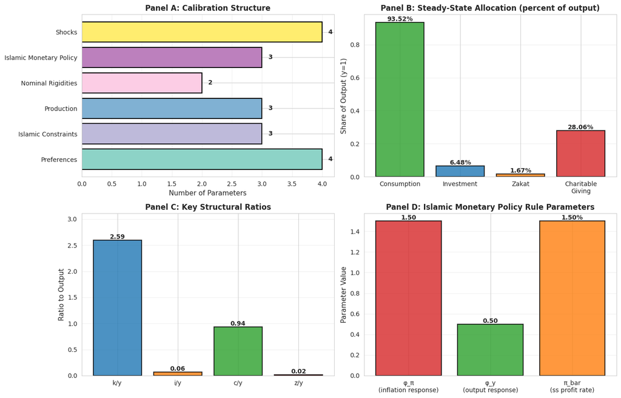

```
Figure 8.5 saved: Calibration
```

```python
# Create visualization of calibration and steady state

fig, axes = plt.subplots(2, 2, figsize=(14, 9))

# Panel 1: Key parameters by category
ax1 = axes[0, 0]
categories = list(calibration.keys())
param_counts = [len(calibration[cat]) for cat in categories]
colors_cat = plt.cm.Set3(np.linspace(0, 1, len(categories)))

ax1.barh(categories, param_counts, color=colors_cat, edgecolor='black', linewidth=1.5)
ax1.set_xlabel('Number of Parameters', fontsize=11)
ax1.set_title('Panel A: Calibration Structure', fontsize=12, fontweight='bold')
ax1.grid(True, alpha=0.3, axis='x')
for i, v in enumerate(param_counts):
    ax1.text(v + 0.1, i, str(v), va='center', fontsize=10, fontweight='bold')

# Panel 2: Steady-state allocation
ax2 = axes[0, 1]
ss_vars = ['Consumption', 'Investment', 'Zakat', 'Charitable\nGiving']
ss_vals = [ss_values['Consumption (c)'], ss_values['Investment (i)'],
           ss_values['Zakat (z)'], ss_values['Charitable Giving (a)']]
colors_alloc = ['#2ca02c', '#1f77b4', '#ff7f0e', '#d62728']

bars = ax2.bar(ss_vars, ss_vals, color=colors_alloc, edgecolor='black', linewidth=1.5, alpha=0.8)
ax2.set_ylabel('Share of Output (y=1)', fontsize=11)
ax2.set_title('Panel B: Steady-State Allocation (percent of output)', fontsize=12, fontweight='bold')
ax2.grid(True, alpha=0.3, axis='y')

for bar in bars:
    height = bar.get_height()
    ax2.text(bar.get_x() + bar.get_width()/2., height,
            f'{height:.2%}', ha='center', va='bottom', fontsize=10, fontweight='bold')

# Panel 3: Key structural ratios
ax3 = axes[1, 0]
ratios = ['k/y', 'i/y', 'c/y', 'z/y']
ratio_vals = [
    ss_values['Capital-Output Ratio (k/y)'],
    ss_values['Investment-Output Ratio (i/y)'],
    ss_values['Consumption (c)'] / ss_values['Output (y)'],
    ss_values['Zakat (z)'] / ss_values['Output (y)']
]
colors_ratios = ['#1f77b4', '#ff7f0e', '#2ca02c', '#d62728']

bars = ax3.bar(ratios, ratio_vals, color=colors_ratios, edgecolor='black', linewidth=1.5, alpha=0.8)
ax3.set_ylabel('Ratio to Output', fontsize=11)
ax3.set_title('Panel C: Key Structural Ratios', fontsize=12, fontweight='bold')
ax3.grid(True, alpha=0.3, axis='y')
ax3.set_ylim(0, max(ratio_vals) * 1.2)

for bar in bars:
    height = bar.get_height()
    ax3.text(bar.get_x() + bar.get_width()/2., height,
            f'{height:.2f}', ha='center', va='bottom', fontsize=10, fontweight='bold')

# Panel 4: Monetary policy parameters
ax4 = axes[1, 1]
mp_params = ['φ_π\n(inflation response)', 'φ_y\n(output response)', 'π_bar\n(ss profit rate)']
mp_vals = [
    calibration['Islamic Monetary Policy']['φ_π (inflation response)'],
    calibration['Islamic Monetary Policy']['φ_y (output response)'],
    calibration['Islamic Monetary Policy']['π_bar (ss profit rate)'] * 100  # Convert to percent
]
colors_mp = ['#d62728', '#2ca02c', '#ff7f0e']

bars = ax4.bar(mp_params, mp_vals, color=colors_mp, edgecolor='black', linewidth=1.5, alpha=0.8)
ax4.set_ylabel('Parameter Value', fontsize=11)
ax4.set_title('Panel D: Islamic Monetary Policy Rule Parameters', fontsize=12, fontweight='bold')
ax4.grid(True, alpha=0.3, axis='y')

for i, bar in enumerate(bars):
    height = bar.get_height()
    if i == 2:
        label = f'{height:.2f}%'
    else:
        label = f'{height:.2f}'
    ax4.text(bar.get_x() + bar.get_width()/2., height,
            label, ha='center', va='bottom', fontsize=10, fontweight='bold')

plt.tight_layout()
plt.savefig(os.path.join(fig_dir, 'fig8_5_calibration.png'), dpi=300, bbox_inches='tight')
plt.show()

print('Figure 8.5 saved: Calibration')
```